# Analisis i entrenament d’un model de machine learning

Isarn i Xavier

2023-03-26

#PREPARACIÓ FITXER latest.qkdb.xml.zip

Amb el programa en python “modificar.xml.py”, afegim les entrades de solution, consequence i diagnosis que no existeixen, perque el programa en R tingui el mateix nombre de files a tots els camps que treballem.

La sortida del programa en python, és: “latest.qkdb.out.zip”, que es guarda en local a la carpeta del codi i que és la entrada de dades que fa servir l’actual codi

#Analitzem si el recompte de paraules de cada opció mostra algun patró per poder entrenar la IA.

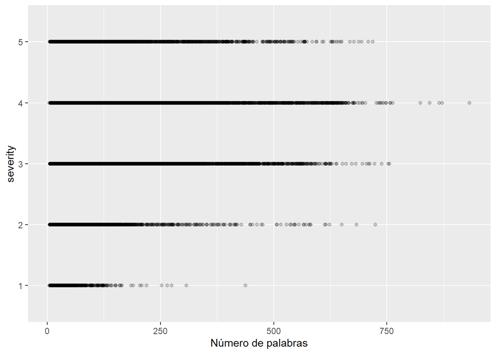

DIAGNOSIS

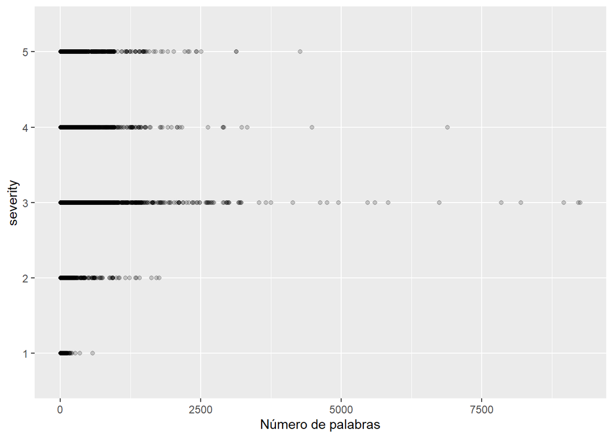

SOLUTION

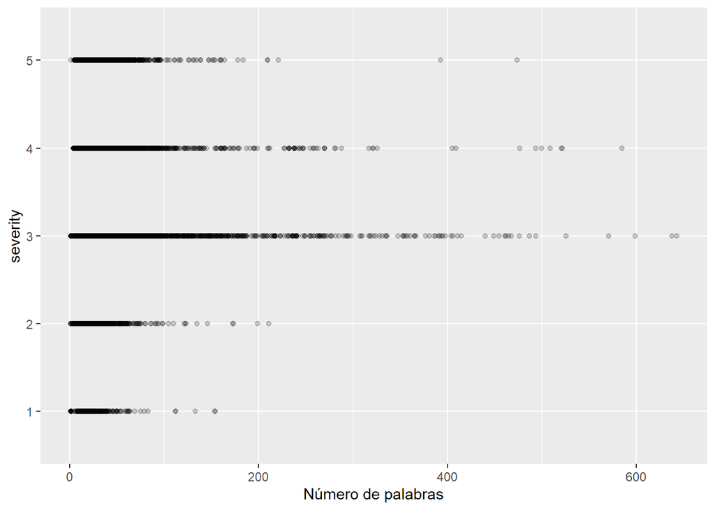

CONSEQUENCE

# Conclusions Gràfic de punts número de paraules vs severitat

De les gràfiques que es mostren, no es poden treure conclusions, ja que no s’hi veu cap relació en cap dels 3 casos, de manera que desestimem aquesta línea de treball, i mirem si analitzant les paraules que apareixen al texte, dona millors resultats

# Origen de dades

En aquest punt, es fa servir els entrenaments amb “DIAGNOSIS”, però utilitzant el fitxer original latest.qkdb.xml.zip.

Accuracy 0.646

# Escollir millor dades d’entrada

S’utilitzen les dades de “DIAGNOSI” com a referència fent servir el fitxer modificat per nosaltres, latest.qkdb.out.zip, però el resultat obtingut tampoc és òptim. S’obté la precisió més baixa.

Accuracy 0,616

# Neteja de dades

Es torna a utilitzar el fitxer modificat latest.qkdb.out.zip. Després, s’eliminen totes les files que estaven buides i que en el seu moment es van omplir amb el títol de les pròpies columnes (“diagnosis”, “solution” i “consequence”). El resultat obtingut no varia molt del inicial ja que la precisió és del 64,6%.

Accuracy 0.646